# Predicting Loan Approval Odds

Author

Emrah Akbas

Published

August 18, 2026

## Classification Models for Machine Learning:

- Logistic Regression
- Tree Model
- Naive Bayes
- SVMs
- Random Forest
- XGBoost

> I will be analyzing a loan approval dataset to predict applicant outcomes. By using data visualization and testing different modeling methods, I will find the most accurate way to predict approvals and denials.

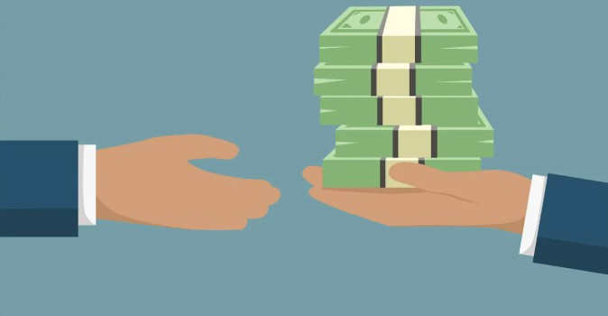

```r
library(readr)
library(tidyverse)
library(ggplot2)
library(GGally)
library(dplyr)
```

Data source : https://www.kaggle.com/datasets/taweilo/loan-approval-classification-data

| Column | Description | Type |
| --- | --- | --- |
| **person_age** | Age of the person | Float |
| **person_gender** | Gender of the person | Categorical |
| **person_education** | Highest education level | Categorical |
| **person_income** | Annual income | Float |
| **person_emp_exp** | Years of employment experience | Integer |
| **person_home_ownership** | Home ownership status (e.g., rent, own, mortgage) | Categorical |
| **loan_amnt** | Loan amount requested | Float |
| **loan_intent** | Purpose of the loan | Categorical |
| **loan_int_rate** | Loan interest rate | Float |
| **loan_percent_income** | Loan amount as a percentage of annual income | Float |
| **cb_person_cred_hist_length** | Length of credit history in years | Float |
| **credit_score** | Credit score of the person | Integer |
| **previous_loan_defaults_on_file** | Indicator of previous loan defaults | Categorical |
| **loan_status** *(target)* | Loan approval status: 1 = approved; 0 = rejected | Integer |

```r
loan <- read_csv("C:/Users/151495/Desktop/Loan Aproval Modeling/loan_data.csv")
str(loan)
```

```
spc_tbl_ [45,000 × 14] (S3: spec_tbl_df/tbl_df/tbl/data.frame)
 $ person_age                    : num [1:45000] 22 21 25 23 24 21 26 24 24 21 ...
 $ person_gender                 : chr [1:45000] "female" "female" "female" "female" ...
 $ person_education              : chr [1:45000] "Master" "High School" "High School" "Bachelor" ...
 $ person_income                 : num [1:45000] 71948 12282 12438 79753 66135 ...
 $ person_emp_exp                : num [1:45000] 0 0 3 0 1 0 1 5 3 0 ...
 $ person_home_ownership         : chr [1:45000] "RENT" "OWN" "MORTGAGE" "RENT" ...
 $ loan_amnt                     : num [1:45000] 35000 1000 5500 35000 35000 2500 35000 35000 35000 1600 ...
 $ loan_intent                   : chr [1:45000] "PERSONAL" "EDUCATION" "MEDICAL" "MEDICAL" ...
 $ loan_int_rate                 : num [1:45000] 16 11.1 12.9 15.2 14.3 ...
 $ loan_percent_income           : num [1:45000] 0.49 0.08 0.44 0.44 0.53 0.19 0.37 0.37 0.35 0.13 ...
 $ cb_person_cred_hist_length    : num [1:45000] 3 2 3 2 4 2 3 4 2 3 ...
 $ credit_score                  : num [1:45000] 561 504 635 675 586 532 701 585 544 640 ...
 $ previous_loan_defaults_on_file: chr [1:45000] "No" "Yes" "No" "No" ...
 $ loan_status                   : num [1:45000] 1 0 1 1 1 1 1 1 1 1 ...
 - attr(*, "spec")=
  .. cols(
  ..   person_age = col_double(),
  ..   person_gender = col_character(),
  ..   person_education = col_character(),
  ..   person_income = col_double(),
  ..   person_emp_exp = col_double(),
  ..   person_home_ownership = col_character(),
  ..   loan_amnt = col_double(),
  ..   loan_intent = col_character(),
  ..   loan_int_rate = col_double(),
  ..   loan_percent_income = col_double(),
  ..   cb_person_cred_hist_length = col_double(),
  ..   credit_score = col_double(),
  ..   previous_loan_defaults_on_file = col_character(),
  ..   loan_status = col_double()
  .. )
 - attr(*, "problems")=<externalptr>
```

## Exploratory Data Analysis

> Several categorical variables are currently formatted as characters. I will convert character (chr) variables into factors. This formatting change ensures they work correctly in our models and calculations.

```r
loan$person_gender <- as.factor(loan$person_gender)
loan$person_education <- as.factor(loan$person_education)
loan$person_home_ownership <- as.factor(loan$person_home_ownership)
loan$loan_intent <- as.factor(loan$loan_intent)
loan$previous_loan_defaults_on_file <- as.factor(loan$previous_loan_defaults_on_file)
loan$loan_status <- as.factor(loan$loan_status)
```

```r
summary(loan)
```

```
   person_age     person_gender     person_education person_income
 Min.   : 20.00   female:20159   Associate  :12028   Min.   :   8000
 1st Qu.: 24.00   male  :24841   Bachelor   :13399   1st Qu.:  47204
 Median : 26.00                  Doctorate  :  621   Median :  67048
 Mean   : 27.76                  High School:11972   Mean   :  80319
 3rd Qu.: 30.00                  Master     : 6980   3rd Qu.:  95789
 Max.   :144.00                                      Max.   :7200766
 person_emp_exp   person_home_ownership   loan_amnt
 Min.   :  0.00   MORTGAGE:18489        Min.   :  500
 1st Qu.:  1.00   OTHER   :  117        1st Qu.: 5000
 Median :  4.00   OWN     : 2951        Median : 8000
 Mean   :  5.41   RENT    :23443        Mean   : 9583
 3rd Qu.:  8.00                         3rd Qu.:12237
 Max.   :125.00                         Max.   :35000
            loan_intent   loan_int_rate   loan_percent_income
 DEBTCONSOLIDATION:7145   Min.   : 5.42   Min.   :0.0000
 EDUCATION        :9153   1st Qu.: 8.59   1st Qu.:0.0700
 HOMEIMPROVEMENT  :4783   Median :11.01   Median :0.1200
 MEDICAL          :8548   Mean   :11.01   Mean   :0.1397
 PERSONAL         :7552   3rd Qu.:12.99   3rd Qu.:0.1900
 VENTURE          :7819   Max.   :20.00   Max.   :0.6600
 cb_person_cred_hist_length  credit_score   previous_loan_defaults_on_file
 Min.   : 2.000             Min.   :390.0   No :22142
 1st Qu.: 3.000             1st Qu.:601.0   Yes:22858
 Median : 4.000             Median :640.0
 Mean   : 5.867             Mean   :632.6
 3rd Qu.: 8.000             3rd Qu.:670.0
 Max.   :30.000             Max.   :850.0
 loan_status
 0:35000
 1:10000
```

```r
over100 <- loan %>%
  filter(person_age > 100)
over100
```

```
# A tibble: 7 × 14
  person_age person_gender person_education person_income person_emp_exp
       <dbl> <fct>         <fct>                    <dbl>          <dbl>
1        144 male          Bachelor                300616            125
2        144 male          Associate               241424            121
3        123 female        High School              97140            101
4        123 male          Bachelor                 94723            100
5        144 female        Associate              7200766            124
6        116 male          Bachelor               5545545             93
7        109 male          High School            5556399             85
# ℹ 9 more variables: person_home_ownership <fct>, loan_amnt <dbl>,
#   loan_intent <fct>, loan_int_rate <dbl>, loan_percent_income <dbl>,
#   cb_person_cred_hist_length <dbl>, credit_score <dbl>,
#   previous_loan_defaults_on_file <fct>, loan_status <fct>
```

> Our data has some unrealistic values, since this is modeling experiment I will keep the extreme values for now.

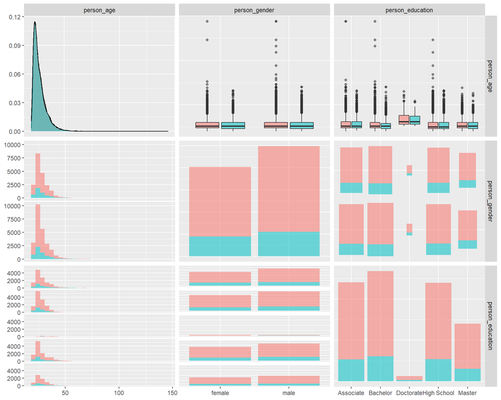

```r
ggpairs(loan,
        columns = c("person_age",
                    "person_gender",
                    "person_education"),
                    aes(color=loan_status, alpha=0.4))
```

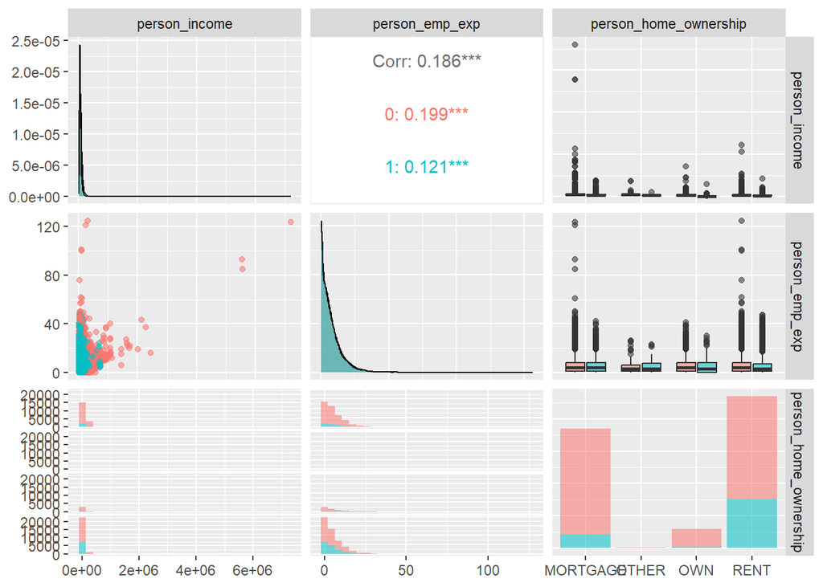

```r
ggpairs(loan,
        columns = c("person_income",
                    "person_emp_exp",
                    "person_home_ownership"),
                    aes(color=loan_status, alpha=0.4))
```

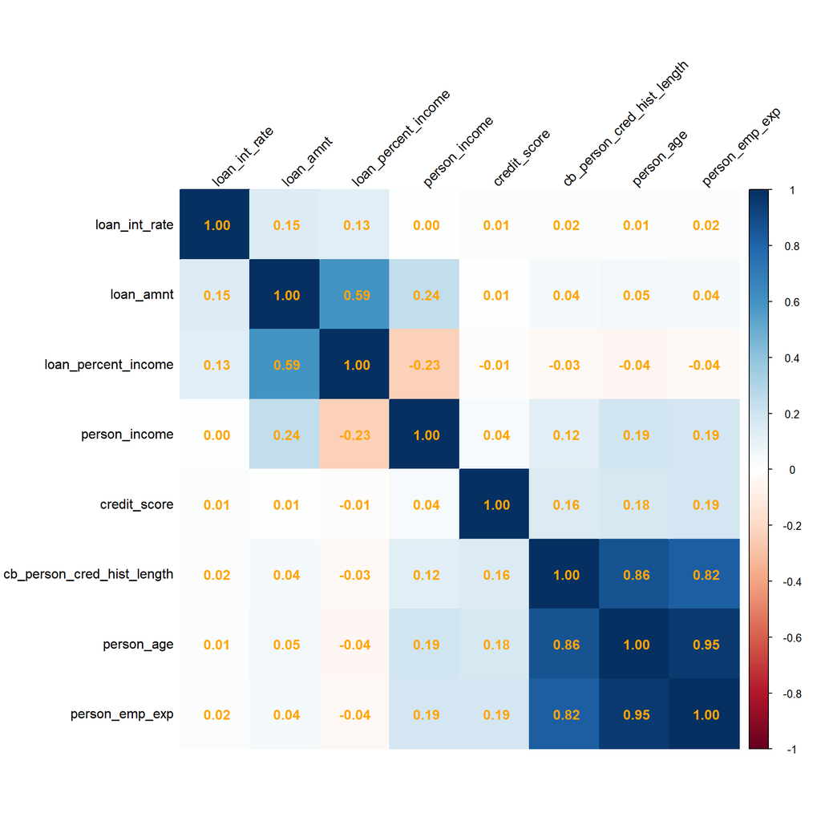

```r
library(corrplot)
matrix <- cor(loan[sapply(loan, is.numeric)])
corrplot(matrix, method = "color",
         order = "hclust",
         addCoef.col = "orange",
         number.cex = 1,
         tl.col = "black",
         tl.srt = 45)
```

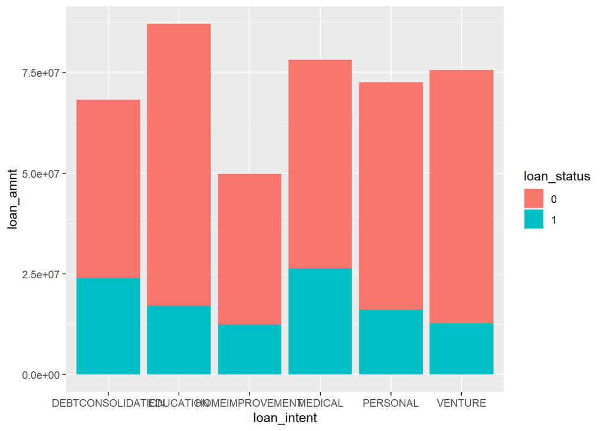

```r
ggplot(loan, aes(x=loan_intent, y=loan_amnt, fill=loan_status)) + geom_col()
```

## Model Fitting and Data Partitioning

> We will split our data into train and test, but first lets fit the logistic regression using all the variables to our entire dataset to get a sense of the variables weight on prediction outcomes.

### Logistic Regression

```r
log_model <- glm(loan_status ~ ., data = loan, family = binomial)
summary(log_model)
```

```
Call:
glm(formula = loan_status ~ ., family = binomial, data = loan)

Coefficients:
                                    Estimate Std. Error z value Pr(>|z|)
(Intercept)                       -3.447e-01  3.594e-01  -0.959  0.33752
person_age                         2.476e-02  1.093e-02   2.267  0.02342 *
person_gendermale                  3.907e-02  3.540e-02   1.104  0.26979
person_educationBachelor          -3.915e-04  4.704e-02  -0.008  0.99336
person_educationDoctorate          1.460e-02  1.476e-01   0.099  0.92122
person_educationHigh School        1.332e-02  4.914e-02   0.271  0.78634
person_educationMaster             3.006e-02  5.624e-02   0.534  0.59303
person_income                      5.889e-07  1.969e-07   2.991  0.00278 **
person_emp_exp                    -2.179e-02  9.710e-03  -2.244  0.02485 *
person_home_ownershipOTHER         3.383e-01  3.188e-01   1.061  0.28857
person_home_ownershipOWN          -1.457e+00  1.018e-01 -14.311  < 2e-16 ***
person_home_ownershipRENT          7.217e-01  4.007e-02  18.009  < 2e-16 ***
loan_amnt                         -1.010e-04  3.940e-06 -25.637  < 2e-16 ***
loan_intentEDUCATION              -9.074e-01  5.851e-02 -15.508  < 2e-16 ***
loan_intentHOMEIMPROVEMENT        -8.255e-03  6.581e-02  -0.125  0.90018
loan_intentMEDICAL                -2.910e-01  5.645e-02  -5.155 2.53e-07 ***
loan_intentPERSONAL               -7.272e-01  5.994e-02 -12.133  < 2e-16 ***
loan_intentVENTURE                -1.211e+00  6.359e-02 -19.044  < 2e-16 ***
loan_int_rate                      3.340e-01  6.574e-03  50.803  < 2e-16 ***
loan_percent_income                1.581e+01  3.072e-01  51.442  < 2e-16 ***
cb_person_cred_hist_length        -5.179e-03  9.109e-03  -0.569  0.56967
credit_score                      -8.911e-03  4.100e-04 -21.732  < 2e-16 ***
previous_loan_defaults_on_fileYes -2.037e+01  1.026e+02  -0.198  0.84268
---
Signif. codes:  0 '***' 0.001 '**' 0.01 '*' 0.05 '.' 0.1 ' ' 1

(Dispersion parameter for binomial family taken to be 1)

    Null deviance: 47674  on 44999  degrees of freedom
Residual deviance: 19879  on 44977  degrees of freedom
AIC: 19925

Number of Fisher Scoring iterations: 19
```

```r
actual_labels <- ifelse(loan$loan_status == 1, "approved", "denied")
```

```r
log_probs <- predict(log_model, type="response")

pred_labels <- ifelse(log_probs >0.5, "approved","denied")

conf_matrix <- table(pred_labels, actual_labels)

table(pred_labels, actual_labels)
```

```
           actual_labels
pred_labels approved denied
   approved     7506   2152
   denied       2494  32848
```

```r
logistic_accuracy <- sum(diag(conf_matrix)) / sum(conf_matrix)
print(paste("Logistic Model Accuracy:", round(logistic_accuracy, 4)))
```

```
[1] "Logistic Model Accuracy: 0.8968"
```

```r
log2_model <- glm(loan_status ~ person_age + person_gender + person_education + log(person_income) +
                     person_home_ownership + loan_amnt + loan_intent + loan_int_rate +
                    loan_percent_income + cb_person_cred_hist_length + credit_score + previous_loan_defaults_on_file,
                  data = loan,
                  family = binomial)
```

```r
log2_probs <- predict(log2_model, type="response")

pred2_labels <- ifelse(log2_probs >0.5, "approved","denied")

conf_matrix2 <- table(pred2_labels, actual_labels)

table(pred2_labels, actual_labels)
```

```
            actual_labels
pred2_labels approved denied
    approved     7593   2184
    denied       2407  32816
```

```r
logistic2_accuracy <- sum(diag(conf_matrix2)) / sum(conf_matrix2)
print(paste("Logistic Model 2 Accuracy:", round(logistic2_accuracy, 4)))
```

```
[1] "Logistic Model 2 Accuracy: 0.898"
```

```r
set.seed(210)

train_data <- sample(nrow(loan), nrow(loan) * 0.8)

train_size <- loan[train_data, ]
test_size <- loan[-train_data, ]

dim(train_size)
```

```
[1] 36000    14
```

```r
dim(test_size)
```

```
[1] 9000   14
```

### Tree Model

```r
library(tree)
```

```r
tree_model <- tree(loan_status ~ ., data = train_size)
summary(tree_model)
```

```
Classification tree:
tree(formula = loan_status ~ ., data = train_size)
Variables actually used in tree construction:
[1] "previous_loan_defaults_on_file" "loan_percent_income"
[3] "loan_int_rate"                  "person_income"
[5] "person_home_ownership"
Number of terminal nodes:  7
Residual mean deviance:  0.4287 = 15430 / 35990
Misclassification error rate: 0.09239 = 3326 / 36000
```

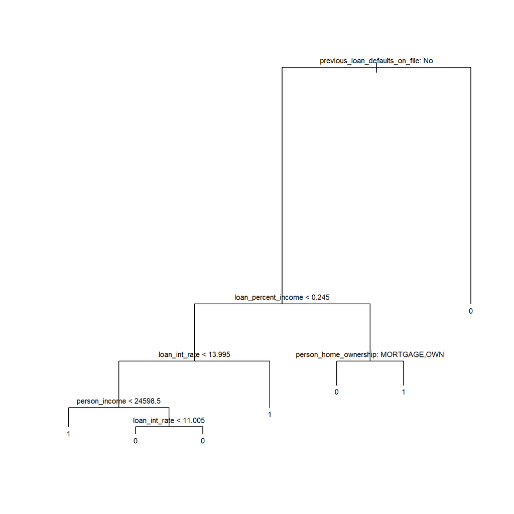

```r
plot(tree_model)
text(tree_model, pretty = 0, cex = 0.7)
```

> The tree starts with previous loan defaults, which is the most important variable. If a person has a previous loan default, the model predicts `loan_status = 0`. If they have no previous default, the tree moves to the next factor, **loan percent income**, with a cutoff of **24.5%**.

> For people with no previous default and a loan percent **income below 24.5%**, the tree looks at the loan interest rate. An interest rate of **13.995%** or higher leads to a prediction of `1`. If the interest rate is below 13.995%, the model then considers person income, using **$24,598.50** as the cutoff.

> Overall, the tree shows that previous loan history, loan burden relative to income, interest rate, income, and home ownership are the main factors used to predict loan status. The model gives the most importance to previous loan defaults, while the other variables provide additional decision points for borrowers who have no previous defaults.

```r
pred_tree <- predict(tree_model, newdata = test_size, type = "class")

conf_matrix_tree <- table(Predicted = pred_tree, Actual = test_size$loan_status)

conf_matrix_tree
```

```
         Actual
Predicted    0    1
        0 6676  610
        1  244 1470
```

```r
accuracy_tree <- mean(pred_tree == test_size$loan_status)

cat("Test Accuracy:", accuracy_tree, "\n")
```

```
Test Accuracy: 0.9051111
```

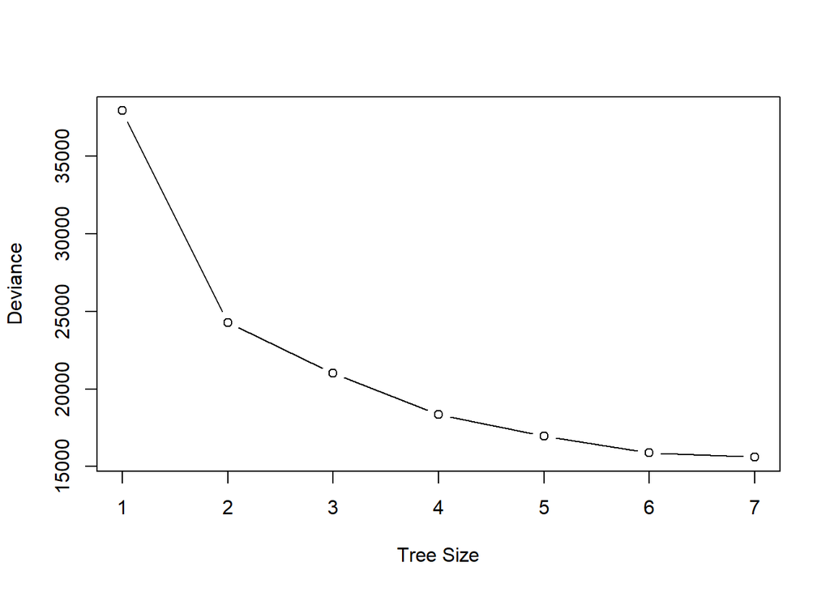

```r
cv_tree <- cv.tree(tree_model)

plot(cv_tree$size, cv_tree$dev, type = "b", xlab = "Tree Size", ylab = "Deviance")
```

```r
best_size <- cv_tree$size[which.min(cv_tree$dev)]
cat("Optimal Tree Size determined by CV:", best_size, "\n")
```

```
Optimal Tree Size determined by CV: 7
```

> This results further confirms that our standard tree model utilized best size on its branches.

### Naive Bayes

```r
library(e1071)
library(caTools)
library(caret)
```

```r
nb_model <- naiveBayes(loan_status ~., data=train_size)
nb_model
```

```
Naive Bayes Classifier for Discrete Predictors

Call:
naiveBayes.default(x = X, y = Y, laplace = laplace)

A-priori probabilities:
Y
   0    1
0.78 0.22

Conditional probabilities:
   person_age
Y       [,1]     [,2]
  0 27.82810 6.089668
  1 27.57184 6.003294

   person_gender
Y      female      male
  0 0.4483974 0.5516026
  1 0.4513889 0.5486111

   person_education
Y    Associate   Bachelor  Doctorate High School     Master
  0 0.26826923 0.29433761 0.01396011  0.26688034 0.15655271
  1 0.26452020 0.30366162 0.01527778  0.26527778 0.15126263

   person_income
Y       [,1]     [,2]
  0 86077.00 91356.16
  1 59783.62 43945.34

   person_emp_exp
Y       [,1]     [,2]
  0 5.467094 6.113810
  1 5.232955 5.961267

   person_home_ownership
Y      MORTGAGE       OTHER         OWN        RENT
  0 0.467236467 0.002172365 0.078917379 0.451673789
  1 0.214772727 0.003409091 0.021212121 0.760606061
```

[output cut: 20 more lines]

```

   cb_person_cred_hist_length
Y       [,1]     [,2]
  0 5.902066 3.873000
  1 5.796212 3.930272

   credit_score
Y       [,1]     [,2]
  0 632.8164 50.36824
  1 632.2072 50.25421

   previous_loan_defaults_on_file
Y          No       Yes
  0 0.3469017 0.6530983
  1 1.0000000 0.0000000
```

> Surprisingly, demographics and credit scores barely matter in this model. Age, gender, education, and credit scores (averaging around 632 for both groups) look almost identical across approved and denied applicants. To make accurate predictions, the model relies heavily on income, loan amount, interest rates, and homeownership rather than basic applicant backgrounds.

```r
nb_preds <- predict(nb_model, newdata = test_size)

conf_matrix_nb <- table(Predicted = nb_preds, Actual = test_size$loan_status)

conf_matrix_nb
```

```
         Actual
Predicted    0    1
        0 6267  448
        1  653 1632
```

```r
accuracy_nb <- sum(diag(conf_matrix_nb)) / sum(conf_matrix_nb)

# Print accuracy as a percentage
print(paste("Accuracy:", round(accuracy_nb * 100, 2), "%"))
```

```
[1] "Accuracy: 87.77 %"
```

### Support Vector Machines (SVMs)

```r
library(caret)
library(kernlab)

control <- trainControl(method = "none") # i didnt want to do cv since dataset is large but I might try on eventually.

# (method = "cv", number = 5)
# tuning_grid <- expand.grid(degree = c(1, 2, 3), scale = c(0.1, 1), C = c(0.1, 1, 10))

# Well I tried running parameters above but the model run time will reach to hours or even days. So this options could be added if there is better computational power is available

svm_model_rad <- train(loan_status ~ .,
                   data = train_size, method = "svmRadial", trControl = control)

svm_preds_rad <- predict(svm_model_rad, newdata = test_size)

confusionMatrix(svm_preds_rad, test_size$loan_status)
```

```
Confusion Matrix and Statistics

          Reference
Prediction    0    1
         0 6626  540
         1  294 1540

               Accuracy : 0.9073
                 95% CI : (0.9012, 0.9132)
    No Information Rate : 0.7689
    P-Value [Acc > NIR] : < 2.2e-16

                  Kappa : 0.728

 Mcnemar's Test P-Value : < 2.2e-16

            Sensitivity : 0.9575
            Specificity : 0.7404
         Pos Pred Value : 0.9246
         Neg Pred Value : 0.8397
             Prevalence : 0.7689
         Detection Rate : 0.7362
   Detection Prevalence : 0.7962
      Balanced Accuracy : 0.8489

       'Positive' Class : 0
```

```r
svm_rad_results <- confusionMatrix(svm_preds_rad, test_size$loan_status)
svm_rad_accuracy <- svm_rad_results$overall["Accuracy"]
print(paste("Radial SVM Accuracy:", round(svm_rad_accuracy, 4)))
```

```
[1] "Radial SVM Accuracy: 0.9073"
```

### Random Forest

```r
library(randomForest)

set.seed(210)
rforest_model <- randomForest(loan_status ~ .,
                         data = train_size,
                         ntree = 600,
                         mtry = 2,
                         importance = TRUE)

rf_preds <- predict(rforest_model, newdata = test_size, type = "response")

rf_matrix <- table(Predicted = rf_preds, Actual = test_size$loan_status)
print(rf_matrix)
```

```
         Actual
Predicted    0    1
        0 6780  520
        1  140 1560
```

```r
rf_accuracy <- sum(diag(rf_matrix)) / sum(rf_matrix)
print(paste("Overall Accuracy:", round(rf_accuracy, 4)))
```

```
[1] "Overall Accuracy: 0.9267"
```

### Extreme Gradient Boosting (XGBoost)

```r
library(xgboost)
```

> first I need to prepare the data for XGBoost

```r
X_train <- model.matrix(loan_status ~ ., data = train_size)[, -1]
X_test  <- model.matrix(loan_status ~ ., data = test_size)[, -1]

y_train <- as.numeric(as.character(train_size$loan_status))
y_test  <- as.numeric(as.character(test_size$loan_status))

dtrain <- xgb.DMatrix(data = X_train, label = y_train)
dtest  <- xgb.DMatrix(data = X_test, label = y_test)
```

```r
params <- list(objective = "reg:logistic",
               max.depth = 4,
               eta       = 0.1
               )

xgb_model <- xgb.train(params  = params,
                        data    = dtrain,
                        nrounds = 50,
                        verbose = 0)
```

```r
xgb_probs <- predict(xgb_model, newdata = X_test)
xgb_preds <- ifelse(xgb_probs > 0.5, 1, 0)

xgb_matrix <- table(Predicted = xgb_preds, Actual = y_test)
print(xgb_matrix)
```

```
         Actual
Predicted    0    1
        0 6708  519
        1  212 1561
```

```r
xgb_accuracy <- sum(diag(xgb_matrix)) / sum(xgb_matrix)
print(xgb_accuracy)
```

```
[1] 0.9187778
```

## Model Comparison

```r
model_comparison <- data.frame(
  Model = c(
    "Logistic Regression",
    " Tree Model",
    "Naiive Bayes",
    "SVMs Model",
    "Random Forest",
    "XGBoost"
    ),
  Accuracy = c(
    logistic_accuracy,
    accuracy_tree,
    accuracy_nb,
    svm_rad_accuracy,
    rf_accuracy,
    xgb_accuracy
    )
  )
```

```r
library(DT)

datatable(
  model_comparison,
  colnames = c("Model Type", "Prediction Accuracy"),
  rownames = FALSE,
  options = list(
    pageLength = 6,
    dom = 't',
    columnDefs = list(list(className = 'dt-center', targets = 0:1))
  )
) %>%
  formatPercentage('Accuracy', digits = 2)
```

| Model Type | Prediction Accuracy |
| --- | --- |
| Logistic Regression | 0.8967555555555555 |
| Tree Model | 0.9051111111111111 |
| Naiive Bayes | 0.8776666666666667 |
| SVMs Model | 0.9073333333333333 |
| Random Forest | 0.9266666666666666 |
| XGBoost | 0.9187777777777778 |

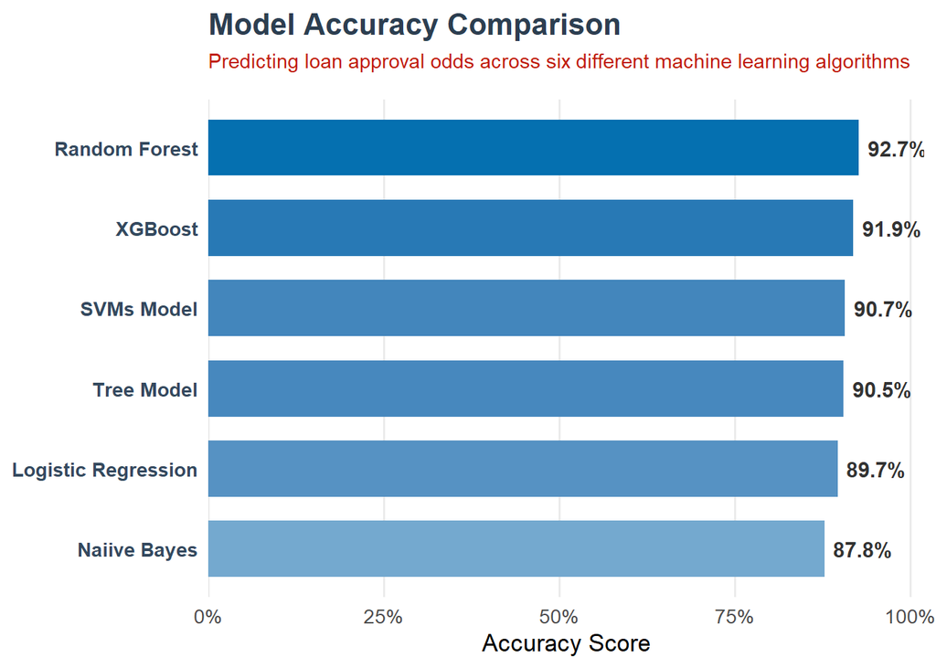

```r
library(ggplot2)
library(dplyr)

model_comparison <- model_comparison %>%
  mutate(Model = reorder(Model, Accuracy))


ggplot(model_comparison, aes(x = Model, y = Accuracy, fill = Accuracy)) +
  geom_col(width = 0.7, show.legend = FALSE) +
    geom_text(aes(label = paste0(round(Accuracy * 100, 1), "%")),
            hjust = -0.15, size = 4, fontface = "bold", color = "grey20") +
  coord_flip() +
  scale_fill_gradient(low = "#74a9cf", high = "#0570b0") +
  scale_y_continuous(labels = scales::percent_format(accuracy = 1),
                     expand = expansion(mult = c(0, 0.1))) +
  labs(
    title = "Model Accuracy Comparison",
    subtitle = "Predicting loan approval odds across six different machine learning algorithms",
    x = NULL,
    y = "Accuracy Score"
  ) +

  theme_minimal(base_size = 13) +
  theme(
    plot.title = element_text(face = "bold", size = 16, color = "#2c3e50"),
     plot.subtitle = element_text(size = 11, color = "#C01D0C", margin = ggplot2::margin(b = 15)),
    axis.text.y = element_text(face = "bold", color = "#34495e"),
    panel.grid.minor = element_blank(),
    panel.grid.major.y = element_blank()
  )
```

## Model Selection and Final Take

> My winning model is Random Forest with impressive accuracy of **92.7%**. This means that my model predict whether person get approve or denied 92.7% of the time.